# ATENCIONES REALIZADAS A LOS ASEGURADOS DEL SEGURO INTEGRAL DE SALUD - ENERO 2019

Maryann Alata Chambilla

2023-03-31

# INICIO

### Descripción del caso

En el Marco de Gobernanza de Datos del Estado Peruano, las entidades de la Administración Pública deben implementar disponibilizan datos de su administración para asegurar un nivel básico y aceptable para la recopilación, procesamiento, publicación, almacenamiento y apertura de los datos que administre. En este sentido, el Seguro Integral de Salud (SIS) publica de manera semestral la información estadística de atenciones que se encuentra bajo la cobertura financiera de alguno de los Regímenes de Financiamiento de la IAFAS SIS.

| ATRIBUTO | DESCRIPCIÓN | TIPO DE DATO |
| --- | --- | --- |
| AÑO | Año de atención | AAAA: año |
| MES | Mes de atención | MM: Mes |
| REGION | Región de atención | Alfanumérico (200) |
| PROVINCIA | Provincia de atención | Alfanumérico (200) |
| UBIGEO_DISTRITO | Código de Ubigeo del distrito de la Atención | Alfanumérico (6) |
| DISTRITO | Distrito de la atención | Alfanumérico (200) |
| COD_UNIDAD_EJECUTORA | Código de la Unidad Ejecutora | Alfanumérica (4) |
| DESC_UNIDAD_EJECUTORA | Unidad Ejecutora de la Atención | Alfanumérica (200) |
| COD_IPRESS | Registro Nacional de Instituciones Prestadoras de Servicios de Salud de Atención (RENIPRESS) | Alfanumérico (200) |
| IPRESS | Institución Prestadora de Servicios de Salud o Establecimiento de Salud de atención | Alfanumérico (200) |
| NIVEL_EESS | Nivel de Establecimiento de Salud I: Nivel I II: Nivel II III: Nivel III | Alfanumérico (1) |
| PLAN_DE_SEGURO | Tipo de seguro SIS, asociado al listado de beneficios (prestados de salud) que brinda su cobertura financiera | Alfanumérico (50) |
| COD_SERVICIO | Código Prestacional | Alfanumérico (3) |
| GRUPO_EDAD | Grupo edad de acuerdo a Normas MINSA Vigente 00-04 Años 05-11 Años 12-17 Años 18-29 Años 30-59 Años 60- más años | Alfanumérico (10) |
| ATENCIONES | Cantidad de Atenciones | Numérico |

Fuente: https://www.datosabiertos.gob.pe/

Para este trabajo, se realizará un Análisis Exploratorio de Datos (AED) con este dataset, para responder a algunas consultas referente alas características y la distribución espacial de los pacientes, durante enero del 2019.

### Lectura y pre-procesamiento de datos

Empezamos importando las librerías necesarias, así como el dataset en cuestión.

```r
## <span style="color : #1135EC"> **MINSA** </span>
# Cargar librerías necesarias
library(tidyverse)
library(readxl)
library(sf)
library(janitor)
library(data.table)
library(grid)
library(gridExtra)
library(ggrepel)

# Lectura de datos
setwd(path)
Data <- read_csv("RDataViz_TF_files/OPENDATA_DS_01_2019_ATENCIONES.csv",
                 locale = locale(encoding="latin1"))

Dep_shp <- read_sf("mapasDpto/DEPARTAMENTOS_inei_geogpsperu_suyopomalia.shp")
Dep_shp <- Dep_shp %>% mutate(NOMBDEP = factor(NOMBDEP, levels = unique(Dep_shp$NOMBDEP))) # Conversión a factor
Dep_points <- Dep_shp %>% st_centroid() # Extracción de centroides
```

```r
Data <- Data %>%
  # Omitir errores de digitación en las categorías del sexo
  filter(SEXO == 'MASCULINO' | SEXO == 'FEMENINO') %>%
  # Unir LIMA METROPOLITANA y LIMA REGIÓN
  mutate(REGION = ifelse(REGION == 'LIMA METROPOLITANA' | REGION == 'LIMA REGION','LIMA', REGION)) %>%
  # Quitar tildes a los departamentos
  mutate(REGION = ifelse(REGION == 'ÁNCASH','ANCHASH', REGION)) %>%
  mutate(REGION = ifelse(REGION == 'APURÍMAC','APURIMAC', REGION)) %>%
  mutate(REGION = ifelse(REGION == 'HUÁNUCO','HUANUCO', REGION)) %>%
  mutate(REGION = ifelse(REGION == 'JUNÍN','JUNIN', REGION)) %>%
  mutate(REGION = ifelse(REGION == 'SAN MARTÍN','SAN MARTIN', REGION)) %>%
  # Corregir errores de digitación en las categorías de edades
  mutate(GRUPO_EDAD = ifelse(GRUPO_EDAD == 'MASCULINO' | GRUPO_EDAD == 'FEMENINO',NA, GRUPO_EDAD)) %>%
  mutate(GRUPO_EDAD = ifelse(GRUPO_EDAD == '00 - 04 años','00 - 04 AÑOS', GRUPO_EDAD)) %>%
  mutate(GRUPO_EDAD = ifelse(GRUPO_EDAD == '05 - 11 años','05 - 11 AÑOS', GRUPO_EDAD)) %>%
  mutate(GRUPO_EDAD = ifelse(GRUPO_EDAD == '12 - 17 años','12 - 17 AÑOS', GRUPO_EDAD)) %>%
  mutate(GRUPO_EDAD = ifelse(GRUPO_EDAD == '18 - 29 años','18 - 29 AÑOS', GRUPO_EDAD)) %>%
  mutate(GRUPO_EDAD = ifelse(GRUPO_EDAD == '30 - 59 años','30 - 59 AÑOS', GRUPO_EDAD)) %>%
  mutate(GRUPO_EDAD = ifelse(GRUPO_EDAD == '60 - mas años','60 - MÁS AÑOS', GRUPO_EDAD)) %>%
  mutate(GRUPO_EDAD = ifelse(GRUPO_EDAD == '60 - MAS AÑOS','60 - MÁS AÑOS', GRUPO_EDAD))

# Conversión a factor
Data <- Data %>%
  mutate(REGION = factor(REGION, levels = unique(Data$REGION))) %>%
  mutate(GRUPO_EDAD = factor(GRUPO_EDAD, levels = unique(Data$GRUPO_EDAD))) %>%
  mutate(SEXO = factor(SEXO, levels = unique(Data$SEXO)))

Data <- na.omit(Data[,-c(1,2)])       # Eliminar columnas de AÑO, MES y omitir filas con NA

str(Data)   # Visualizar las características del dataset
```

```
## tibble [1,028,390 x 15] (S3: tbl_df/tbl/data.frame)
##  $ REGION               : Factor w/ 25 levels "AMAZONAS","ANCHASH",..: 1 1 1 1 1 1 1 1 1 1 ...
##  $ PROVINCIA            : chr [1:1028390] "BAGUA" "BAGUA" "BAGUA" "BAGUA" ...
##  $ UBIGEO_DISTRITO      : chr [1:1028390] "010206" "010206" "010206" "010206" ...
##  $ DISTRITO             : chr [1:1028390] "LA PECA" "LA PECA" "LA PECA" "LA PECA" ...
##  $ COD_UNIDAD_EJECUTORA : chr [1:1028390] "0955" "0955" "0955" "0955" ...
##  $ DESC_UNIDAD_EJECUTORA: chr [1:1028390] "REGION AMAZONAS - SALUD BAGUA" "REGION AMAZONAS - SALUD BAGUA" "REGION AMAZONAS - SALUD BAGUA" "REGION AMAZONAS - SALUD BAGUA" ...
##  $ COD_IPRESS           : chr [1:1028390] "0000005049" "0000005049" "0000005049" "0000005049" ...
##  $ IPRESS               : chr [1:1028390] "LA PECA" "LA PECA" "LA PECA" "LA PECA" ...
##  $ NIVEL_EESS           : chr [1:1028390] "I" "I" "I" "I" ...
##  $ PLAN_DE_SEGURO       : chr [1:1028390] "SIS GRATUITO" "SIS GRATUITO" "SIS GRATUITO" "SIS GRATUITO" ...
##  $ COD_SERVICIO         : chr [1:1028390] "019" "021" "024" "056" ...
##  $ DESC_SERVICIO        : chr [1:1028390] "DETECCIÓN TRASTORNO AGUDEZA VISUAL Y CEGUERA" "PREVENCION DE CARIES" "DETECCIÓN PRECOZ DE CÁNCER CÉRVICO-UTERINO" "CONSULTA EXTERNA" ...
##  $ SEXO                 : Factor w/ 2 levels "FEMENINO","MASCULINO": 1 1 1 2 1 2 1 1 1 1 ...
##  $ GRUPO_EDAD           : Factor w/ 6 levels "12 - 17 AÑOS",..: 1 2 3 1 3 2 2 1 2 4 ...
##  $ ATENCIONES           : chr [1:1028390] "4" "6" "1" "8" ...
##  - attr(*, "na.action")= 'omit' Named int [1:808] 112574 122563 124971 126395 126396 131700 131701 140651 140669 225148 ...
##   ..- attr(*, "names")= chr [1:808] "112574" "122563" "124971" "126395" ...
```

# ANÁLISIS POR EDAD Y SEXO

### ¿Cuál es el rango de edad más y menos frecuente entre los pacientes?

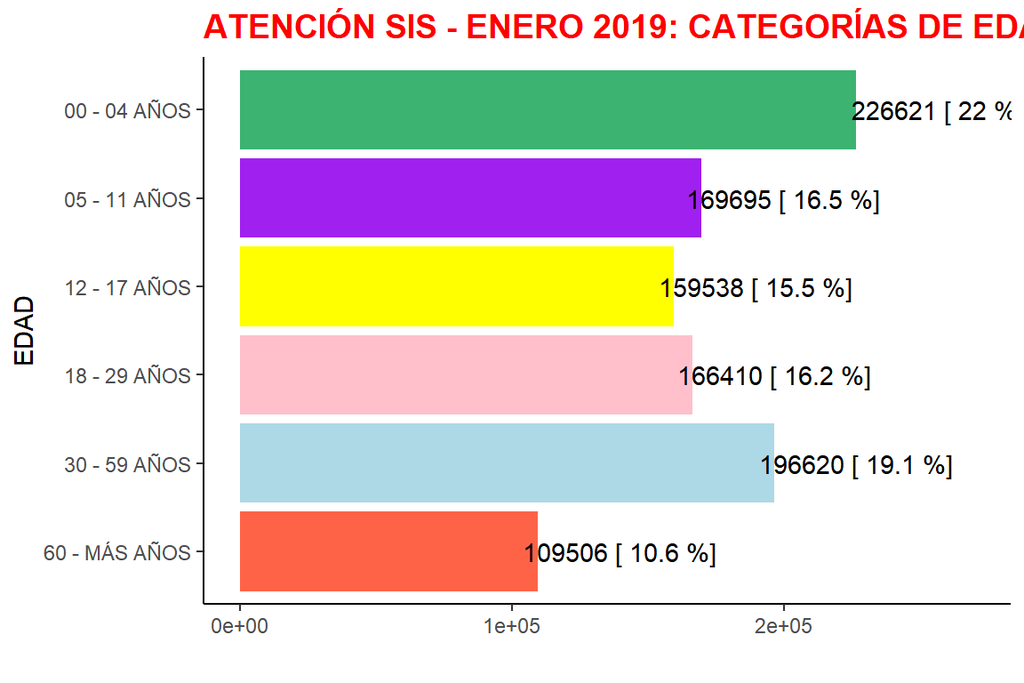

De la gráfica anterior, se deduce que la mayor proporción de pacientes tienen entre 0 y 4 años (22% del total), mientras que los mayores a 60 años son menos frecuentes (10.6%).

### ¿Cómo es la distribución del sexo del paciente por cada categoría de edad?

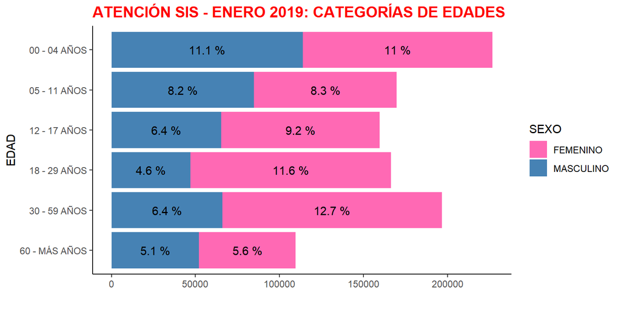

# ANÁLISIS TERRITORIAL

### ¿Cuáles son los departamentos con más y menos pacientes?

De la siguiente figura, se concluye que Lima y Cajamarca son los departamentos con mayores pacientes registrados, sumando juntos más del 20% del total. En tanto, Tumbes y Moquegua son los que menor n° de registros cuentan, sumando poco más del 1% del total.

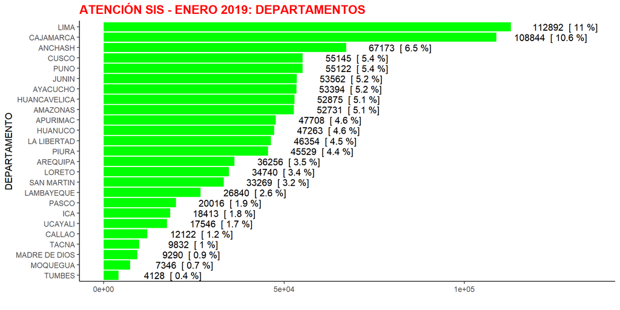

### ¿Cuáles son las regiones del país con mayor y menor pacientes atendidos?

Del siguiente, se concluye que la costa central y parte de la sierra norte registran la mayor cantidad de pacientes; en tanto, la sierra central y sur registran una moderada cantidad de pacientes; al contrario de parte de la costa sur y la selva centro-sur, que son las regiones con menor información.

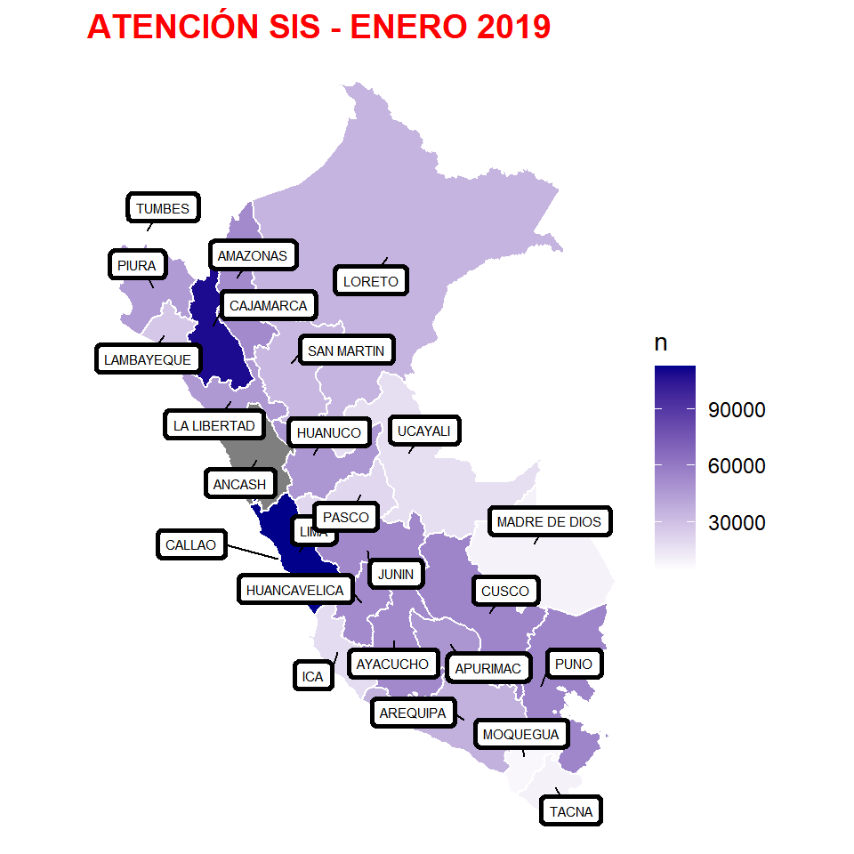

### Considerando la edad y sexo del paciente ¿Cuáles son las características más comúnes a nivel nacional?¿Dónde se concentran?

A nivel nacional, predomina las pacientes femeninas de entre 30 y 59 años, excepto en la sierra norte, donde predominan los pacientes masculinos de entre 0 a 4 años. Se diferencia Loreto, donde predomina las pacientes femeninas de entre 18 y 29 años.

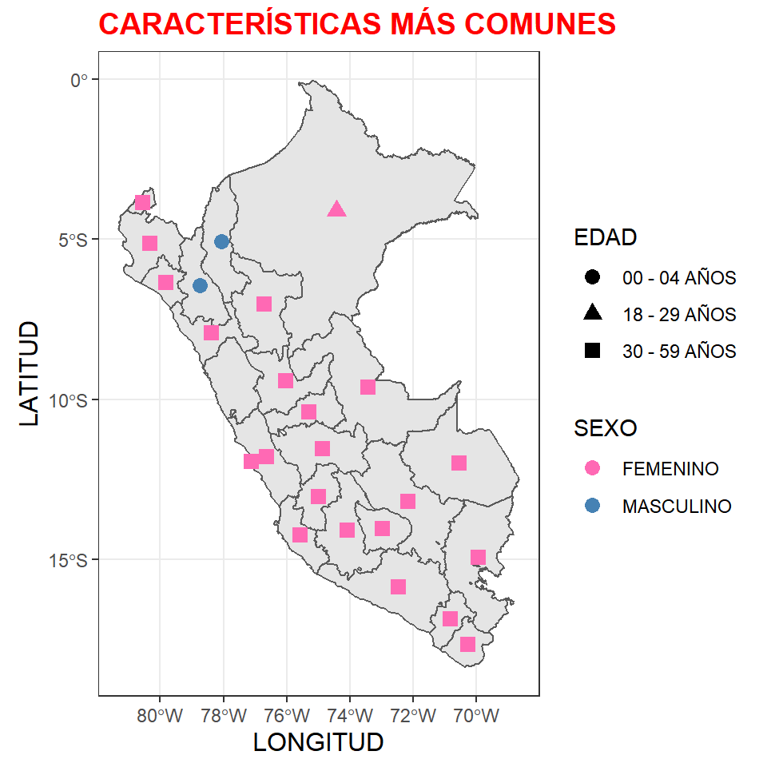